# Polimp-analysis

Erica Yoon

March 30, 2015

```r
rm(list = ls())
library(jsonlite)
library(ggplot2)
library(tidyr)
source("../helper/useful.R")

raw.data.path <- "../../production-results/"

## LOOP TO READ IN FILES
all.data <- data.frame()
files <- dir(raw.data.path,pattern="*.json")

for (file.name in files) {
  print(file.name)

  ## these are the two functions that are most meaningful
  json_file <- readLines(paste(raw.data.path,file.name,sep=""))
  json_file_str = paste(json_file, collapse = "")
  json_file_str = gsub(",}", "}", json_file_str)
  jso = jsonlite::fromJSON(json_file_str)
  jso1 <- data.frame(jso)
  jso1$subid <- substring(file.name, 1, 6)

  ## now here's where data get bound together
  all.data <- rbind(all.data, jso1)
}
```

```
## [1] "304SM51WA34HRGX90JNLUEAQV68SBE.json"
## [1] "30BUDKLTXDVESHBIYEC32B6JKLXE5M.json"
## [1] "30H4UDGLT2IGXFLEZR90DPG9KNPMP5.json"
## [1] "30LSNF239UVY9PUHCE0WPJ1ZS4C2IH.json"
## [1] "32RIADZISS4X6HC0L4DYM04KLGAS4V.json"
## [1] "333U7HK6I9FH7AC3RL5DX3732ATJDM.json"
## [1] "33PPO7FECVFLCZSX93KDL2S3PV0DI0.json"
## [1] "354GIDR5ZB6G6KANT17C0R8O9CE003.json"
## [1] "35BLDD71I6XT16HT0S8TRJ10LF7VZF.json"
## [1] "35L9RVQFCOI7X6SZPGSHVQVCBIHUHZ.json"
## [1] "35L9RVQFCOI7X6SZPGSHVQVCBILHUQ.json"
## [1] "36W0OB37HWEOJ5M9V3RPCIARD0WZHT.json"
## [1] "378XPAWRUCDNESPLPTTBV1KX4S7IA7.json"
## [1] "37W3JXSD6686B57TUGB6ZEBCMU4WYY.json"
## [1] "38YMOXR4MUZ4SLXNOXGEGNRJNKFW62.json"
```

[output cut: 39 more lines]

```r
levels(all.data$answer.scale) <- c("hateA_alsoHateB", "hateA_butLoveB", "loveA_butHateB", "loveA_alsoLoveB", "someHate_alsoAllHate", "someHate_butNotAllHate", "someLove_butNotAllLove", "someLove_alsoAllLove", "training1", "training2")
levels(all.data$answer.judgment) <- c("No", "Maybe", "Yes")
```

Filter out participants and clean up.

```r
d <- all.data %>%
  select(subid, answer.scale, answer.judgment) %>%
  rename(judgment = answer.judgment) %>%
  filter(answer.scale != "training1" & answer.scale != "training2") %>%
  separate(answer.scale, into = c("utterance", "inference"), sep = "_")

d$inference <- as.factor(d$inference)

d <- d %>%
  mutate(bound = factor(substring(inference, 1, 3),
                           levels = c("als", "but"),
                           labels = c("also  (lower)", "but not  (upper)")),
         scale = factor(as.numeric(grepl("some", utterance)),
                        levels = c(0, 1),
                        labels = c("ad-hoc","scalar")),
         utt_valence = factor(as.numeric(grepl("love", utterance,
                                               ignore.case=TRUE)),
                            levels = c(0, 1),
                            labels = c("hate", "love")),
         inf_valence = factor(as.numeric(grepl("love", inference,
                                               ignore.case=TRUE)),
                            levels = c(0, 1),
                            labels = c("hate", "love")),
         condition = str_c(utt_valence, "-", inf_valence))
```

## Scalar inferences

Prediction - “but not all” infrence should be cancelled in the face-threatening context (hate-hate). In contrast, should be stronger in the love-love hypothesis

Not sure what the prediction is for the “also all” condition. Should probably be the flip?

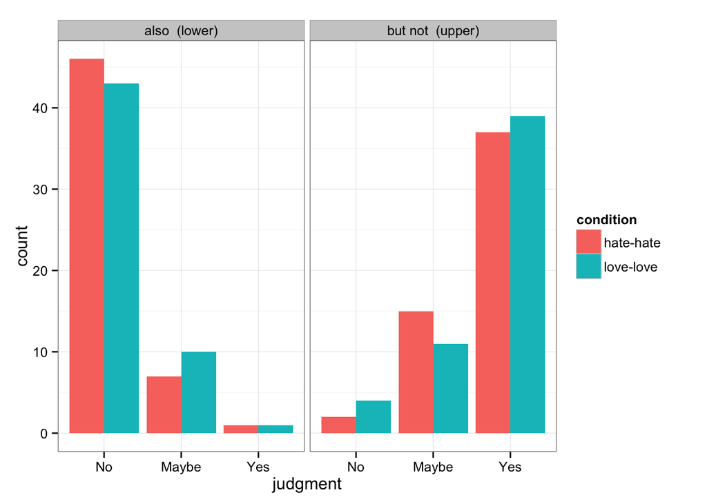

```r
qplot(judgment, fill = condition, position = "dodge",
      data = filter(d, scale == "scalar")) +
  facet_grid(~bound)
```

We find little support for this hypothesis, but there is a trend in this direction, perhaps.

## Ad hocs

Prediction - in face-threatening context, inference should be cancelled. So:

- hateA should not imply ~hateB (because they could have hated both, but you didn’t want to say)
- loveA should more strongly imply ~loveB (because if they have loved both it would have been nice to say so)
- hateA should imply ~loveB (because you could have said something nicer)
- loveA should not imply ~hateB (because it wouldn’t be nice to say so).

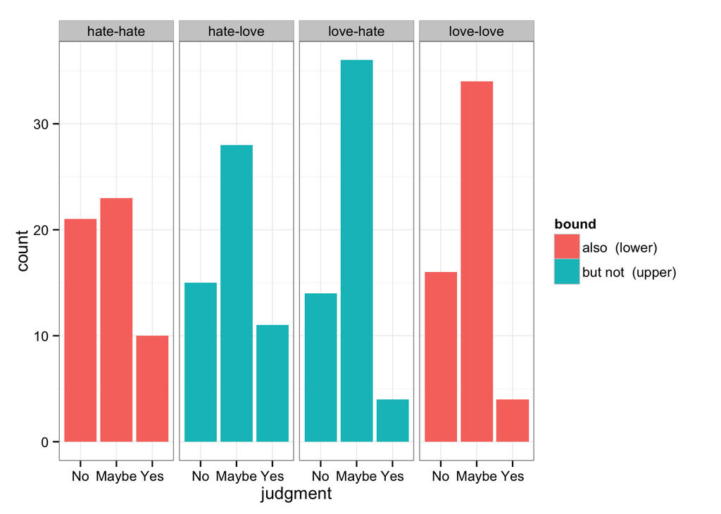

```r
qplot(judgment, fill = bound, position = "dodge",
      data = filter(d, scale == "ad-hoc")) +
  facet_grid(~condition)
```

These predictions aren’t exactly satisfied, but certainly the number of “maybes” is very different in the love scenarios than the hate scenarios.

[output not shown]